# Low SHAPE/low Shannon entropy analysis of DENV2 genome

This is a recreation of an analysis in Figure 1 from Dethoff et al. 2018. Data files were obtained from the authors. pdf

- DENV2_EX_1M7_MAP.map
- DENV2_EX-Diff_BP-prob.dp
- DENV2_EX-Diff_MFE.ct

These files were originally produced by performing SHAPE-MaP, analyzing resulting sequencing reads using ShapeMapper, and then producing a secondary structure model and base pairing probabilities using SuperFold.

In this example, we will analyze SHAPE-MaP data from the Dengue 2 viral genome. low SHAPE, low Shannon entropy (lowSS) regions in a long RNA can be used to detect regions of well-defined structure. Functional elements tend to be over-represented in these lowSS regions. These regions are defined by low SHAPE reactivity, indicating low local nucleotide flexibility, and by low Shannon entropy, a measure of likelihood to form alternative structures.

```python
import rnavigate as rnav
```

## Define the experimental sample and provide input file names

```python
denv = rnav.Sample(
    sample="DENV2 Genome",
    shapemap="DENV2_EX-1M7_MAP.map",
    pairprob="DENV2_EX-Diff_BP-prob.dp",
    ss="DENV2_EX-Diff_MFE.ct")
```

## Plot results of the low SHAPE, low Shannon entropy analysis

First, we will perform the lowSS analysis. By default, this step will produce a full-length plot. However, DENV2 is 10732 nt, which is a bit unweildy, so we will set `region=[1, 2000]` to limit the visualization to nucleotide positions 1 through 2000.

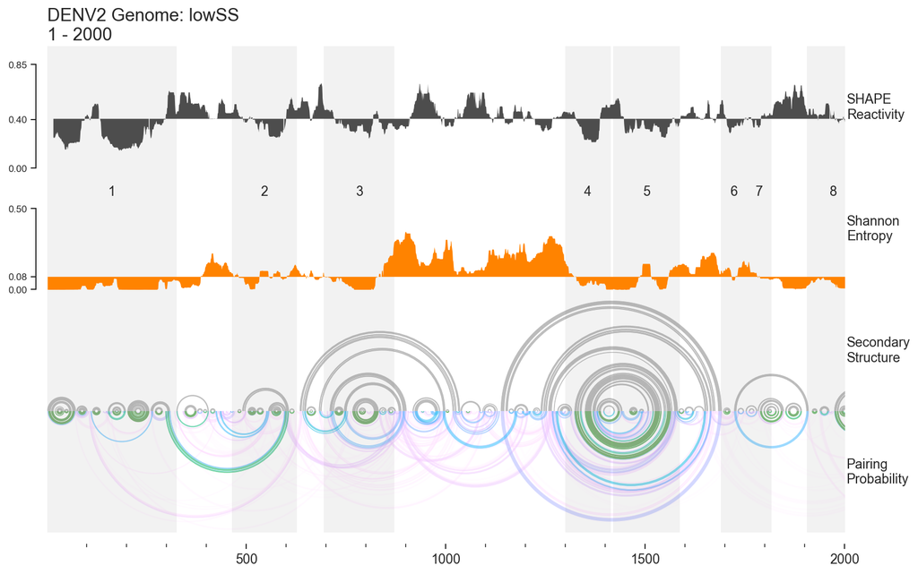

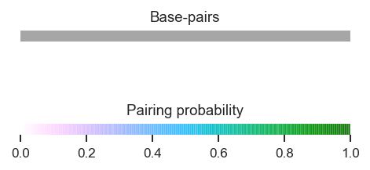

```python
analysis = rnav.analysis.LowSS(sample=denv)
plot = analysis.plot_lowss(region=[1,2000])

# plot.save("denv_lowss.svg")
```